# Smoking Paper - Appendix A

## Figure A6 - Correlations log2FC diff. abund vs log2FC regression on daily smoking intensity

**Figure A6. Scatterplot and correlation index between effect size estimates in the differential abundance contrasting Current over Never smokers and the effect size estimates for the regression of genera abundance in relation to the daily grams of tobacco smoked daily**. Both methods used DESeq2 regression correcting for age group, sex, number of teeth. , however in the comparison between Current and Never smokers a contrast between factors was extract (log2 Fold Change), in the second case the estimates were step-wise fold change direction in response to increasing 5 grams smoked per day (0, 5, 10, …, 30).

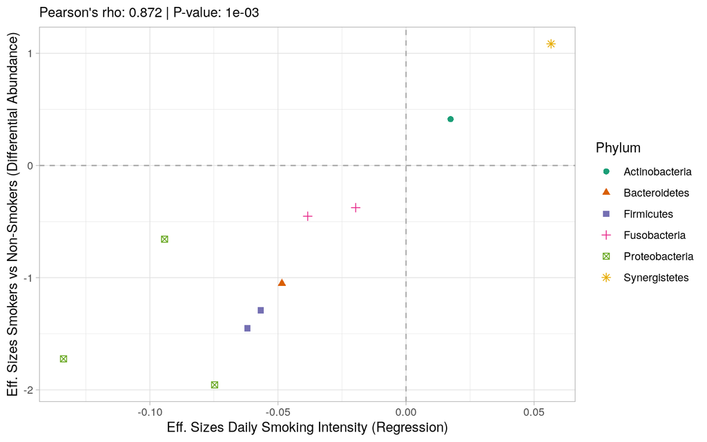

```r
> q1_results <- readRDS("/home/gantonello/CHRISMB/PAPER_DRAFTS/smoking-paper-genus/Main/results/Figure1/DiffAbundGenera/significant_genera_Consensus-and-log2FC.RDS") %>%
+   dplyr::filter(taxon %in% readRDS("/home/gantonello/CHRISMB/PAPER_DRAFTS/smoking-paper-genus/Main/results/Figure1/DiffAbundGenera/significant_genera_consensus.RDS")) %>%
+   column_to_rownames("taxon") %>%
+   rowMeans(na.rm = T) %>%
+   as.data.frame() %>%
+   rownames_to_column("Genus") %>%
+   set_names(c("Genus", "Q1_log2FC"))
>
> q2_results <- readRDS("/home/gantonello/CHRISMB/PAPER_DRAFTS/smoking-paper-genus/Main/results/Figure2/deseq_smoking_regression_datafames.rds") %>%
+   .$x0sm61_bin5cont %>%
+   as.data.frame() %>%
+   filter(padj < 0.05)
>
> data_for_plot <- inner_join(q1_results, q2_results, by = "Genus")
>
>
> ############# actual plot and significance
>
> pearson_rho <- cor.test(data_for_plot$Q1_log2FC, data_for_plot$log2FoldChange, method = "pearson")
> library(RColorBrewer)
>
> fig.A6 <- data_for_plot %>%
+
+   ggplot(aes(x = log2FoldChange, y = Q1_log2FC, color = Phylum, shape = Phylum))+
+   geom_point(size = 2)+
+   geom_hline(yintercept = 0, lty = "dashed", color = "darkgray")+
+   geom_vline(xintercept = 0, lty = "dashed", color = "darkgray")+
+   labs(
+        y = "Eff. Sizes Smokers vs Non-Smokers (Differential Abundance)",
+        x = "Eff. Sizes Daily Smoking Intensity (Regression)",
+        subtitle = paste("Pearson's rho:", round(pearson_rho$estimate, 3), "| P-value:", format(pearson_rho$p.value, scientific = TRUE, digits = 2)))+
+   scale_color_brewer(palette = "Dark2")
>
>
> ggsave(plot = fig.A6,
+        filename = "appendix_results/A6/A6_eff_sizes_DESeq2_proportional.png",
+        width = 7,
+        height = 5,
+        dpi = 300
+        )
>
> fig.A6
```